# Analyzing resting-state EEG and Spelling Performance in Young Adults (Quadratic Plateau) VERSION2

Leandro Ledesma

2026-01-29

**DISCLAIMER: Code compatible to run on the SAS 9 Computer**

**This is supposed to be a shorter version (summary) of the Rmarkdown with the original analysis**

### Universal block code settings

```r
knitr::opts_chunk$set(echo = FALSE)
knitr::opts_chunk$set(message = FALSE)
knitr::opts_chunk$set(comment = NULL)
knitr::opts_chunk$set(warning = FALSE)
```

### Loading in our data and doing some data cleaning

Here we are loading demographic and medical information

- demographic information (age, sex)
- Medical information (to remove DD or head injuries)

After some minor data cleaning we combine the information into one dataset.

If there are NAs in the ID variable then those observations (rows) get dropped and any IDs that do not correspond to the first study (there are three of them) will also be removed.

### Loading in the ARFA Spelling data

- Here we will be loading ARFA spelling error data. This data has already been processed from an earlier script where each item had the potential to have several different types of errors. For example, each item had 7 variables where scores were given to indicate errors or even Russian words were used. No errors were rows where each of the 7 variables had all 0’s, which was most of the dataset. What we are loading in below are **sum of errors for each item** capped at two (0, 1, 2). We capped it at two because that was recommended to us.

### Visualizing the ARFA Spelling Data

Below we can visualize the distribution of total item error score (not the same as total number of incorrect items). Additionally, we can see the frequency of the number of errors by item.

Descriptive Statistics of Spelling Total Error Score

| vars | n | mean | sd | median | trimmed | mad | min | max | range | skew | kurtosis | se |
| --- | --- | --- | --- | --- | --- | --- | --- | --- | --- | --- | --- | --- |
| 1 | 661 | 14.97 | 9.63 | 13 | 14.15 | 10.38 | 0 | 41 | 41 | 0.65 | -0.41 | 0.37 |

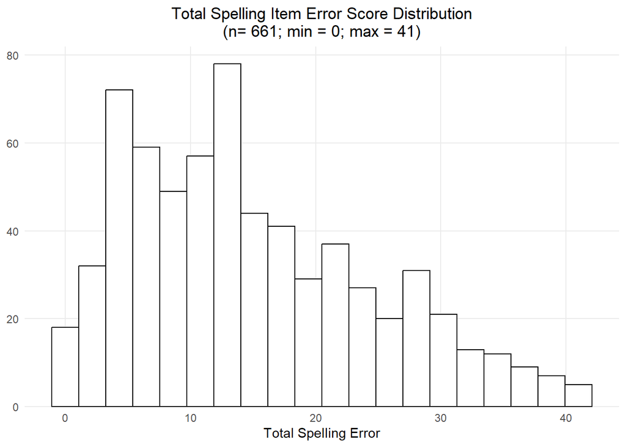

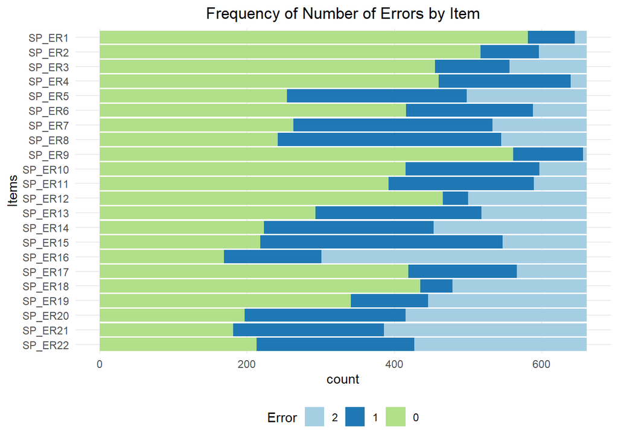

### Running a Graded Response Model (Item Reponse Theory Model)

We technically already did this in another R script. However, we will be redoing it again here to explain exactly how the process works better. Essentially, from the graphs above, we can see that each item contains 3 different types of categories (no mistakes = 0, one mistake = 1, at least two mistakes = 2). Thus, we can use a **graded response model** to basically estimate difficulty and discrimination parameters for each item. Additionally, we can extract standardized error scores for each observation (ID), which we will use as a precursor for our predictor of interest.

The model produces standardized error scores, but then we multiplied these values by **negative one** to turn them into accuracy measures. Afterwards, we introduce these values into our main dataset with demographic and medical information.

What is plotted are the original theta values that represent errors. Additionally we show another plot that shows the graded response model parameters, indicating item level information. Unfortunately, I have no idea how to interpret these values.

```
Calculating information matrix...
```

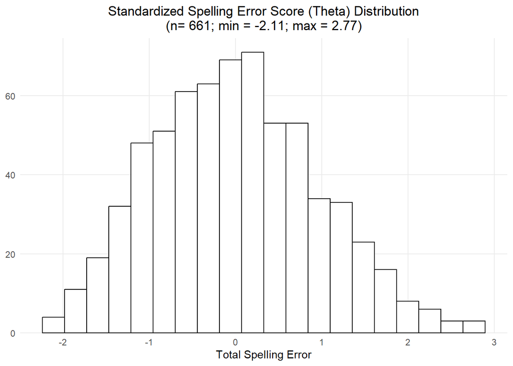

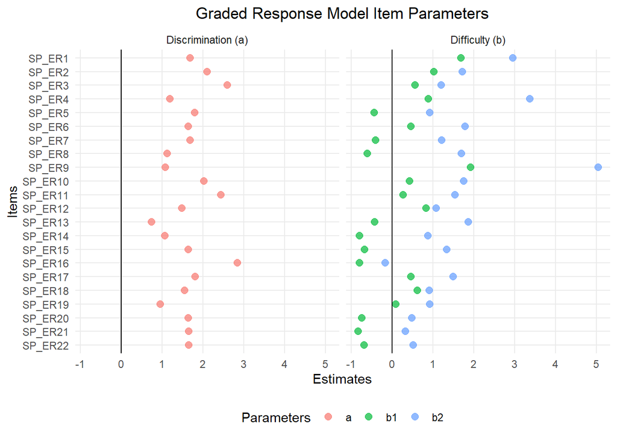

### Loading EEG Information

Here we are loading two types of EEG information:

- Individual power spectra (FFT) of rsEEG recordings
- An EEG quality control (QC) CSV

The **power spectra** holds information of our resting-state EEG outcome. The analysis in subsequent sections will be attempting to explain the variance of this for the several frequency bands. The QC will be used to remove recordings that were problematic during the preprocessing stage- this occurs in the next section.

During this data cleaning code section, we are:

- Identifying two rsEEG recordings that need to be renamed
- Removing data from 5 recordings, one which was redundant, four because they were not real IDs (not sure what they are)
- Use interpolated channel x trial segments to identify channels as ‘bad’ (e.g., if 90% of the channel was interpolated then we should mark that as a bad channel)

The information in this section should **not** count toward reporting ‘x’ number of IDs removed

```
rsEEG IDs that need to be renamed (RAW -> ID)
```

```
# A tibble: 2 × 2
  ID    RAW
  <chr> <chr>
1 34867 34857
2 97991 97911
```

```
It it should say 0 below if it worked and IDs were renamed
```

```
[1] 0
```

### Remove subjects that do not meet criteria (Behaviorally)

This is the exclusion criteria: - Self-report injury - Epilepsy - ADD - Too old compared to average (more than 3 Sd from the mean) - Do not have spelling data (this is information is needed to make spelling groups later on) - **Note**: Calculating z-scores must be done before removing any IDs from the dataset- this prevents recalculating z-scores and have another extreme value appear when previously it wasn’t!

*Update- modification occurred, we will now keep dyslexics and ppl with low performance on the CFIT in the data*

We use the `slice_head()` function since this is information from level-2 predictors- this will speed up the code.

Here we will be removing subjects that do not meet the behavior criteria. There is another section that will follow where we further exclude subjects who do not have adequate EEG data.

[output not shown]

```
We are removing 143 participants for having head trauma, epilepsy, autism, ADD, extremly poor spellers (3SD +), or older than 3SD from the mean
```

```
  HeadTrauma Health2epilepsy Health2autism ADD Dislexia Too_old MissingSpell
N        108             141           142  50      125     133          126
Y         35               2             1  93       18      10           17
```

```
This leaves us with data from 516 participants who may or may not have an EEG recording
```

```
numeric(0)
```

```
numeric(0)
```

### Early Demographics

The demographics before we removed bad EEG recordings - The sample size for Age is three less than it should be because of NAs

```
   vars   n  mean   sd median trimmed  mad min max range skew kurtosis   se
X1    1 513 20.12 4.29     19   19.43 2.97  15  33    18 1.27     0.91 0.19
```

```
   F    M
0.57 0.43
```

```
 BF  IC
271 242
```

```
[1] "516 unique IDs"
```

### Descriptives of QC of our EEG data (Eyes Closed Only)

Below we can visualize different EEG QC measures to get a feel for how problematic EEG recordings were and in which aspect. These QC metrics were derived from MATLAB preprocessing code where custom functions were used to identify number of bad channels, trials, and overall data interpolation. With the exception of bad trials that used a threshold of SD =4, every other metric used a threshold of SD = 5. Specifically, this was using robust zscores since they are less likely to be inflated by skewed data.

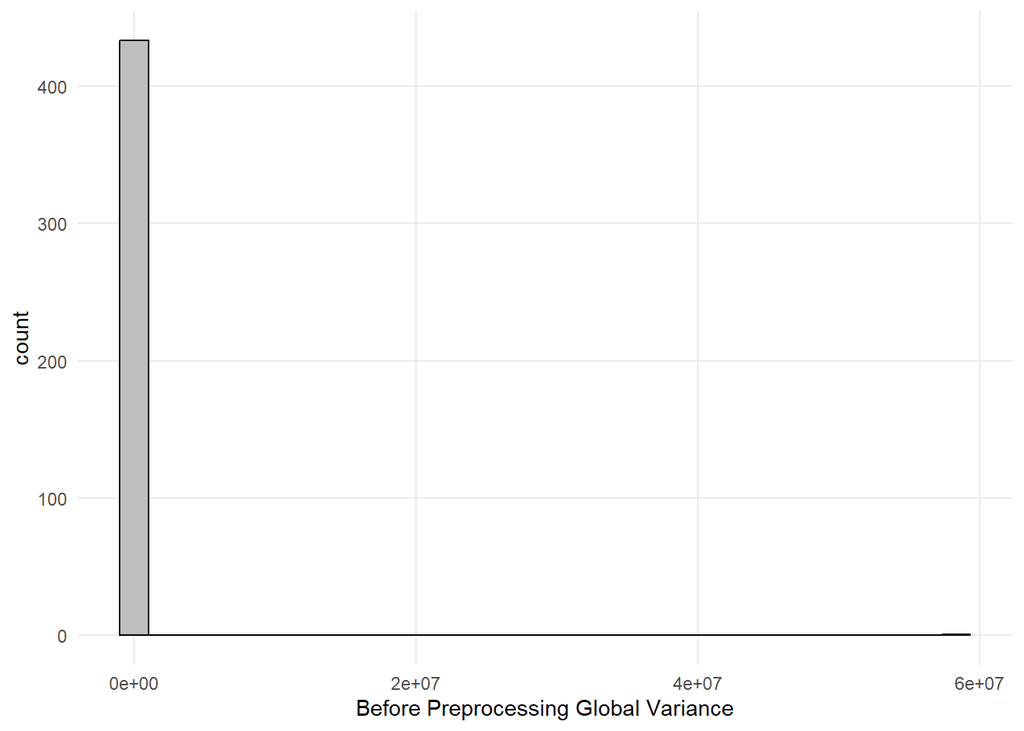

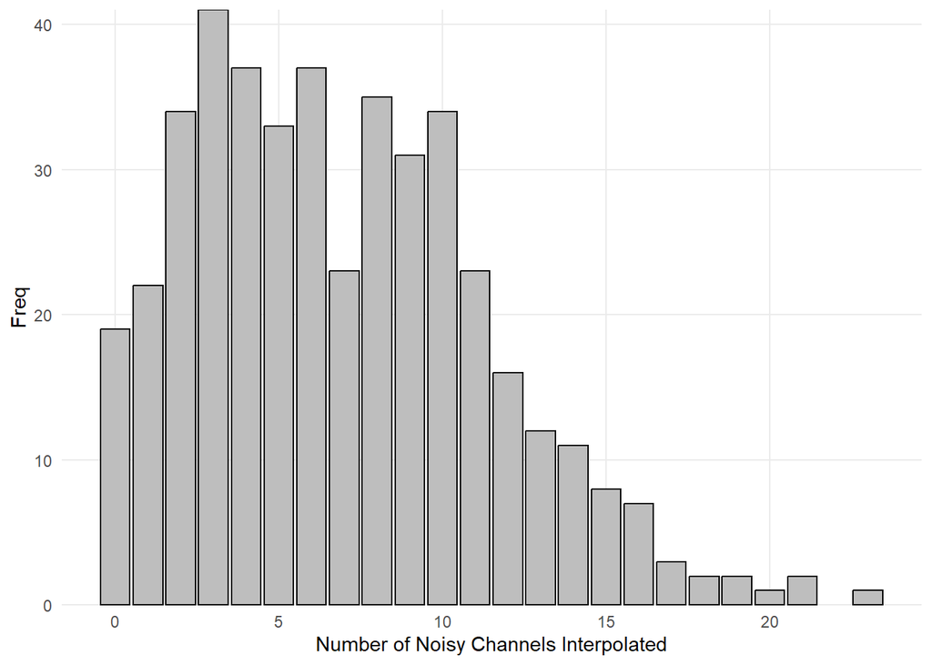

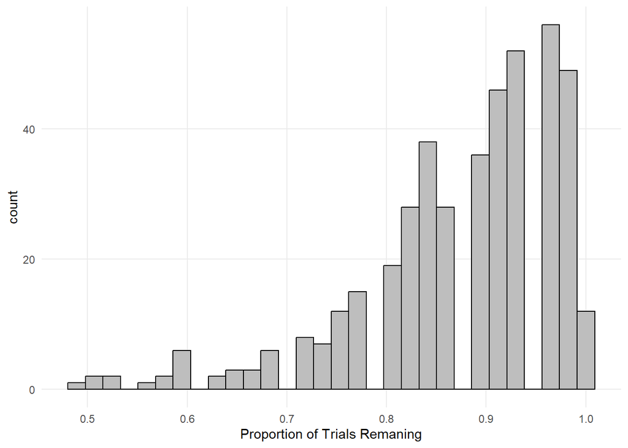

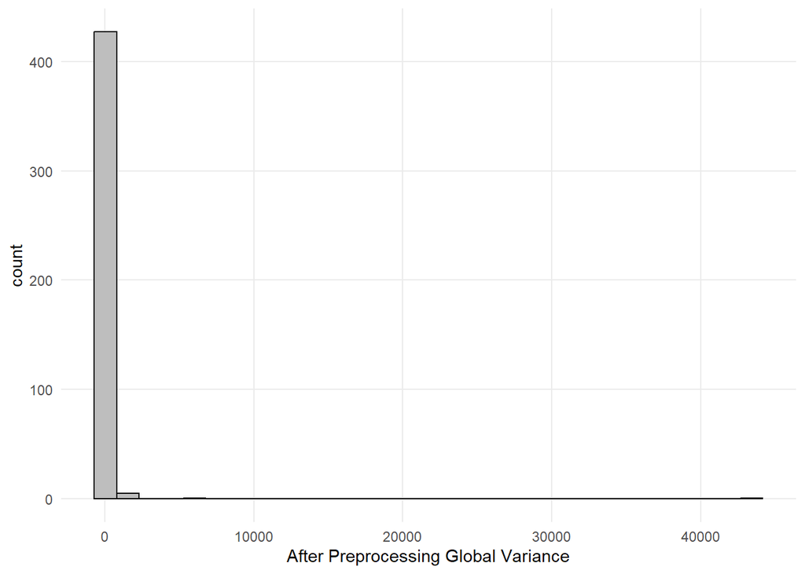

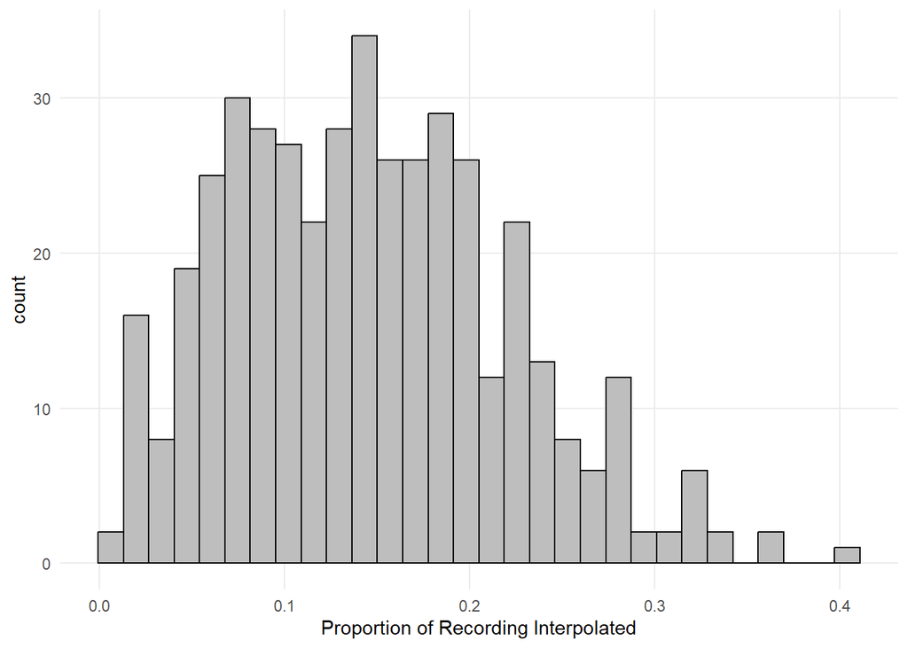

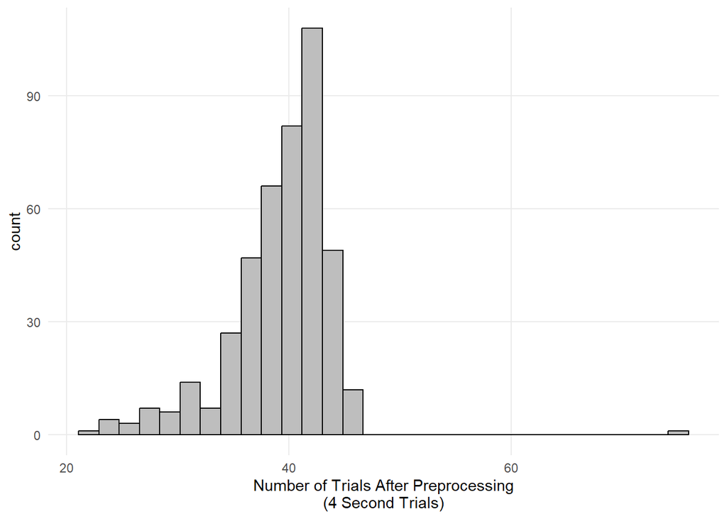

# Identifying how many EEG recordings are good

Below we created the exclusion criteria for EEG recordings that will not be analyzed. Also anyone missing EEG data will be removed. While mixed-effects models can handle missing data, we cannot for certain state that these data were missing at random and also around 80 something files are missing EEG or their EEG data did not make the cut. I don’t think we need to rely on this information for our analysis.

Below we specified what makes a good recording. The recordings need to:

- Have less than 18% of channels be interpolated or marked as bad. Since there are 62 channels in each recording, 62 * .18 = 11.16. Thus, if a recording has 12 or more bad channels they will not be used for analysis.
- Have at least 30 trials, each being 4 seconds long, which will result in 2 minutes worth of EEG recordings.
- Have missing EEG data, they will be fully removed.
- And if their ending global variance is larger than 4 robust z-scores then they will be removed. This means that we calculate the MAD score instead of the standard deviation, which is more robust to outliers, and multiply this value by 4 and add it to the mean of ending global variance. Any recordings with an ending global variance that exceeds this threshold will be removed.

```
Recordings split by whether they have enough trials (min = 30 )
```

```
Not_Engh_EEG
  N   Y
416  18
```

```
Recordings split by whether they exceed acceptable channel interpolation proportion from  62  channels (max = 0.18 )
```

```
Many_Chan_Intp
  N   Y
369  65
```

```
Had an ending global variance that exceeded 4 MAD above the mean
```

```
HigEndVar
  N   Y
427   7
```

```
IDs that did not have EEG data at all
```

```
Missing_EEG
  N   Y
434  82
```

```
Number and percentage of recordings that need to be excluded
```

```
Exclusion
  N   Y
352 164
```

```
Exclusion
   N    Y
0.68 0.32
```

```
Missing data of the observations (IDs) that will be used in the final analysis
```

```
             S1              ID             Sex             Age           Group
              0               0               0               0               0
     HeadTrauma Health2epilepsy   Health2autism             ADD        Dislexia
             30             352             352              30              30
     theta_good       Condition     start_trial   start_globvar       trialsrmv
              0               0               0               0               0
      end_trial trialpropremain     end_globvar       int_total         channel
              0               0               0               0               0
      frequency           power        elec_pop       elec_flat       elec_nois
              0               0               0               0               0
        int_AF3         int_AF4         int_AF7         int_AF8         int_AFz
              0               0               0               0               0
         int_C1          int_C2          int_C3          int_C4          int_C5
              0               0               0               0               0
         int_C6         int_CP1         int_CP2         int_CP3         int_CP4
              0               0               0               0               0
        int_CP5         int_CP6         int_CPz          int_Cz          int_F1
              0               0               0               0               0
         int_F2          int_F3          int_F4          int_F5          int_F6
              0               0               0               0               0
         int_F7          int_F8         int_FC1         int_FC2         int_FC3
              0               0               0               0               0
        int_FC4         int_FC5         int_FC6         int_FCz        int_FT10
              0               0               0               0               0
        int_FT7         int_FT8         int_FT9         int_Fp1         int_Fp2
              0               0               0               0               0
         int_Fz          int_O1          int_O2          int_Oz          int_P1
              0               0               0               0               0
         int_P2          int_P3          int_P4          int_P5          int_P6
              0               0               0               0               0
         int_P7          int_P8         int_PO3         int_PO4         int_PO7
              0               0               0               0               0
        int_PO8         int_POz          int_Pz          int_T7          int_T8
              0               0               0               0               0
        int_TP7         int_TP8        chan_rmv       chan_rmv2    Not_Engh_EEG
              0               0               0               0               0
 Many_Chan_Intp     Missing_EEG       HigEndVar       Exclusion
              0               0               0               0
```

# Introducing Topography and Frequency Band Variables

We will start with the information present in the data frame that was created in the previous section. We will use the IDs that basically ‘survived’ for having adequate behavioral and EEG data and use that as an index for the dataset that contains all of the within-individual (group) variables (e.g. channels, frequency).

Here we will remove variables (columns) that are not much of interest to us and introduce frequency band (FB) and topography as factors. These factors are designed to simply our data, since right now each recording has power values across individual frequencies (this is also called the **Power Spectra Density**) for each of the 62 electrodes. Eventually we will use these factors to reduce the dimensions of the data, but for now we used the `summary()` function in combination with the `group_by()` function to keep the same dimension. This is so that in subsequent sections we can plot the power spectra without issues.

Also, all recordings below are **eyes closed** only!

The frequency bands chosen follow that from Whitford’s paper (2007), where they had:

- Slow waves: 0.5 - 7.5 Hz
- Alpha waves: 8 - 12 Hz
- Beta waves: 12.5 - 34.5 Hz

- Frontal: c(“Fp1”, “Fp2”, “F7”, “F3”, “Fz”, “F4”, “F8”, “FC3”, “FCz”, “FC4”)
- Temporal: c(“T7”, “TP7”, “T8”, “TP8”)
- Parietal: c(“CP3”, “CPz”, “CP4”, “P3”, “Pz”, “P4”)
- Occipital: c(“O1”, “Oz”, “O2”)

# Plotting the Power Spectra Density (Averaging Across Channels)

Below we are plotting the **power spectral density (PSD)** of our data. This basically means that we have power values (uV^2) for different frequencies (Hz), that’s it, there is nothing more complicated that goes to this. For a source that corroborated this, please visit:

https://liquidinstruments.com/blog/what-is-power-spectral-density-and-why-is-it-important/

Anyway, the PSD is different from **absolute power**, where we take PSD and then sum them within frequency bands. Note that the correct way to calculate absolute power is by taking the sum and not the mean!

If we wanted to calculate relative power, essentially, or the proportion of power explained by that frequency, then we can sum up the power values across the range of our frequencies (0.5 - 35 Hz by 0.25 Hz, which is 139 frequencies) and then just divide each PSD by that sum. The reason why we have power values corresponding to 0.25 Hz is because our EEG segments are 4 seconds long, thus the **frequency resolution**, calculated by 1/seconds = 1/4 seconds = 0.25.

Anyway, thinking about our full long dataset, we have power values that correspond to a range of frequencies (139). Every recording has this information for 62 channels (62 * 139 = 8,618). This is too much information to plot. So instead what we can do is start by averaging across channels within each person, so now every will have a PSD comprised of 139 values that represent the overall PSD. Anyway to accomplish this we can take our long dataset and group it by ID and frequency and obtain an average power across channels- this will be our starting point.

Next, we will take this information and this time average across participants to get a PSD that represents that information for all subjects. This information will then be embedded ontop of the plots as a black line. Now while this is great to visualize, this information is misleading. This is because the aggregate we are plotting is derived from using all channel information in our data. However, as we specified in the previous section, we are only using information from 23 channels in the final analysis, specifically by aggregating across channels of interest within topographical regions of interest. Therefore, we did the same here by averaging across channels of interest within the 4 topographical regions we care for and the plotted that along with the PSD that was further averaged across subjects.

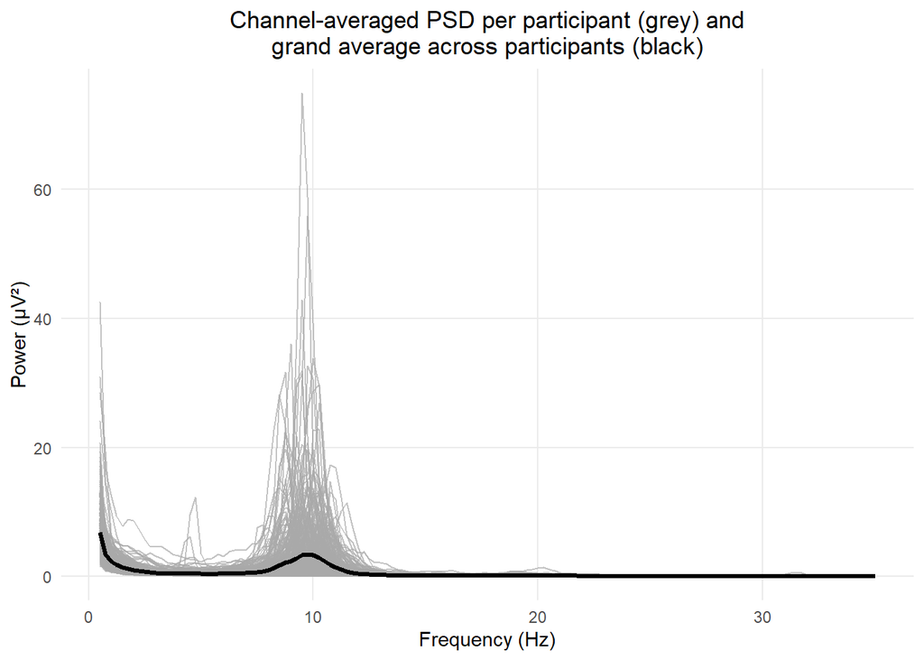

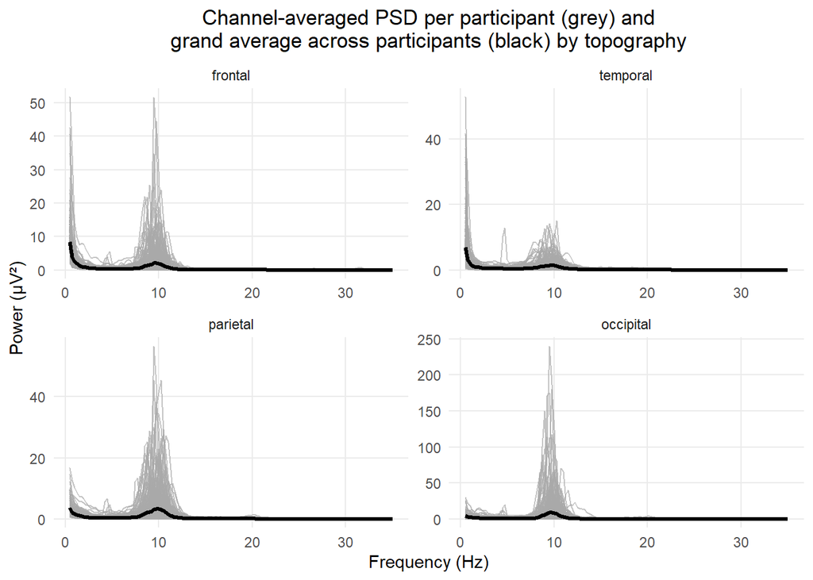

# Calculating Absolute Power (Data Reduction)

We are starting back with our long dataset and this time we will be using it to calculate **absolute power**. We used Grok’s help to basically accomplish this. Okay so we established that each subject has 8,618 observations (62 * 139 = 8,618). We do not care for information from 62 channels, we are only interested in information from 23 of them, so we will start by filtering out channels we do not care for. The easiest way to do this is just to drop observations where topography has NA’s, because these are channels that were not labeled for any of the 4 topography groups.

What we have now per person is 3,197 observations (23 * 139 = 3,197). What we need to do now is simplify our data, or reduce the number of observations by averaging across channels within our frequency bands of interest. This will result in a PSD for 4 topographies for each person (4 * 139 = 556 observations).

Absolute power is defined as the **sum of power values** within frequency bands. So the next step will be to sum power values within topographical regions. We have three frequency bands of interest (slow, alpha, beta), so the 556 observations will be isolated into 4 mutually exclusive groups (topography), from those groups which represent PSD, we will create sub groups of PSD within frequency bands (4 * 3 = 12 topography x frequency band groups), and from these groups we will take the chunked PSD values and sum them together for each person! Additionally, we will multiply this sum by the frequency resolution, which is 0.25. This apparently makes the values actual absolute power, but regardless when we analyze the data we will still get the same results had we not done this.

Therefore, each subject will now have 3 * 4 = 12 power values. With this information, we can also group by either frequency bands or frequency band * topography level combinations and calculate z-scores. In the plots below we can see the consequence of calculating z-scores failing to account for topography, the data becomes very skewed. However when including topography it looks a lot more reasonable, but still skewed. Since we are going to use models that require a normally distributed outcome, we must have to do some transformation to our data.

So in plots below, we also take the log of the outcome and then conver these values into z-scores. From the plots we see that in the log scale values are no longer that extreme, aka not that far away from the mean, which means that our analysis will probably work on our outcome (absolute power) in this scale.

This also means that we do not need to remove subjects for having ‘extreme’ scores since the log scores all look reasonable. Therefore our next section can just be us reporting our final sample size now that the removing subjects phase is concluded.

```
Data points per person, should sum to 12
```

```
           FB
topography  slow alpha beta
  frontal      1     1    1
  temporal     1     1    1
  parietal     1     1    1
  occipital    1     1    1
```

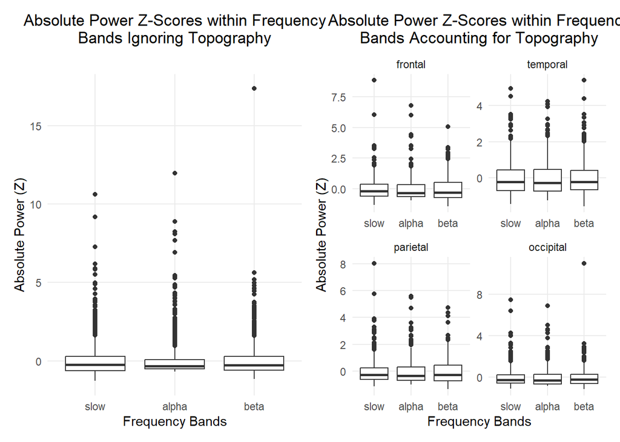

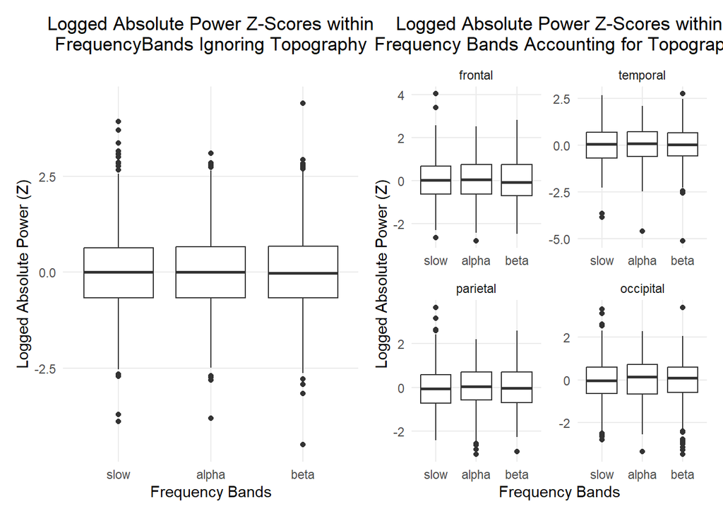

# Final Demographics

From this point on, no observations will be removed from our data. Thus, here we will report our final sample size a long with descriptives of our data. Lastly, we will also show missing values for each variable. There should be no missing values in our predictors, covariates, and outcomes of interest.

```
There are 352 unique IDs in our sample and each one should have 12 observations, for a total of 4224 observations
```

```
Counting the number of rows in the data, there are 4224 rows
```

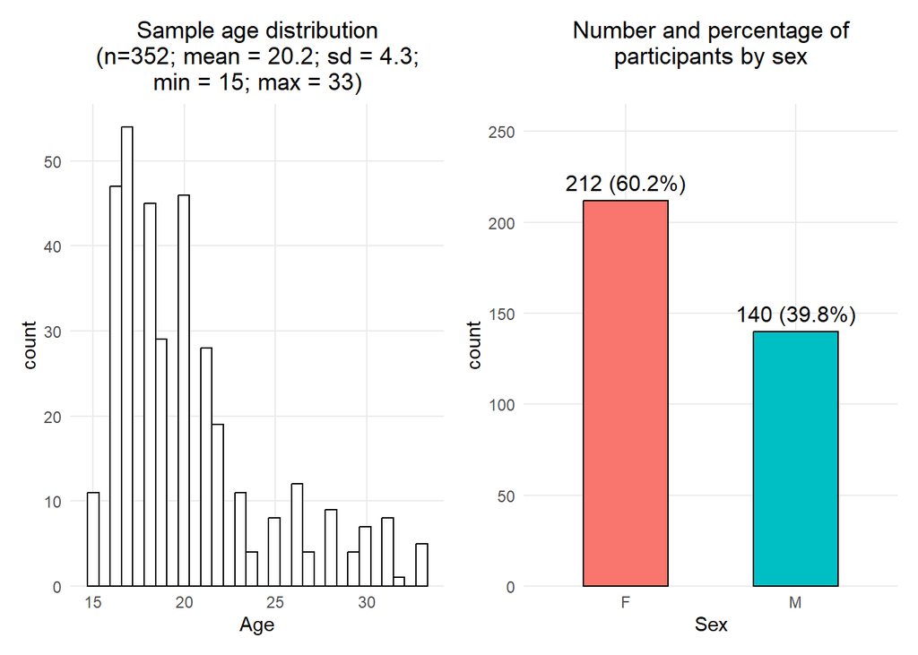

```
Here are values representing missing data for each variable in the final dataset
```

```
            ID     topography             FB            Sex            Age
             0              0              0              0              0
    theta_good absolute_power
             0              0
```

# Visualizing the Distribution of Absolute Power Within Topographies and in Relation to Age

The histograms of absolute power grouped for each topography are showing that the data is pretty skewed to the right. This is problematic because in order for us analyze our data we need to see a normal distribution to produce stable and reliable standard errors. Now this is not always the case, what really matters is the distribution of your errors, however this is a good shortcut to predict whether our errors will look normal or not.

In Whitford’s paper, they also report that their distribution of absolute power for their sample was skewed also to the right. Since their analysis involved using regression, they needed their outcome distribution (absolute power) to look normal, thus they square root their data.

Below we are doing something similar, we are plotting the distribution of absolute power in its original scale, after the values were transformed with the square root and a transformation of values using logarithm. We see below that our data looks best (normally distributed) when we use the log transformations.

Additionally we are also showing the scatterplot between that transformation of the outcome (absolute power) and age. These descriptives give us a hint on whether or not we see that with age absolute power decreases, which theoretically is something we would expect.

We can kinda see this with the slow wave, where with age the absolute power of the slow wave (0.5 - 7.5 Hz) decreases, however for alpha and beta we do not see this relationship.

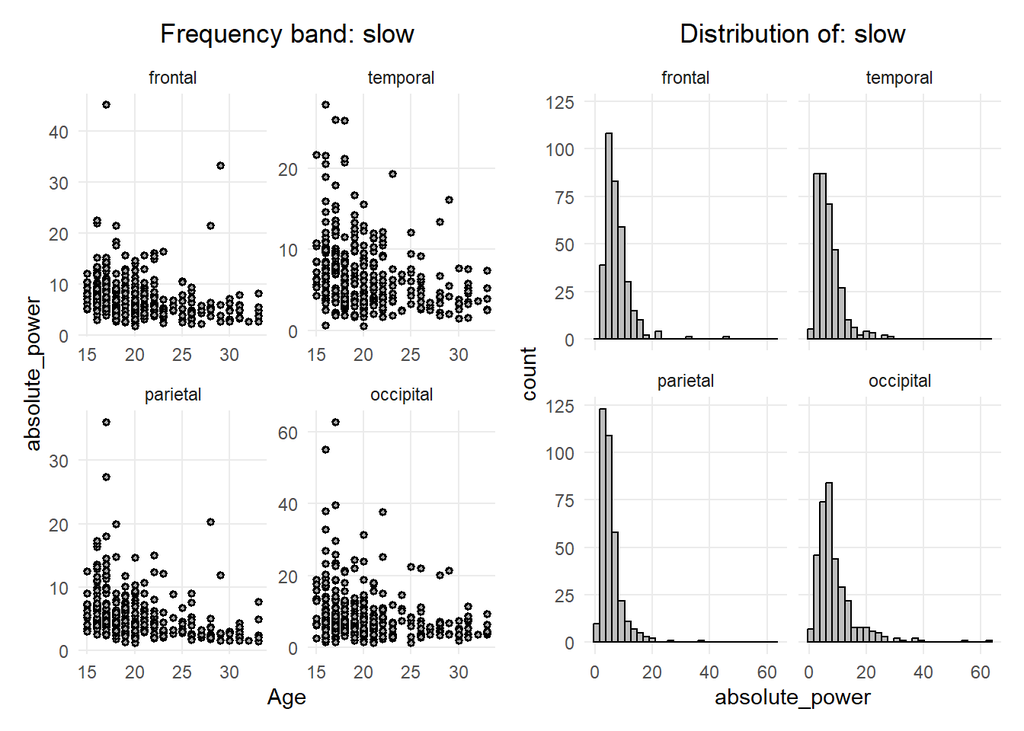

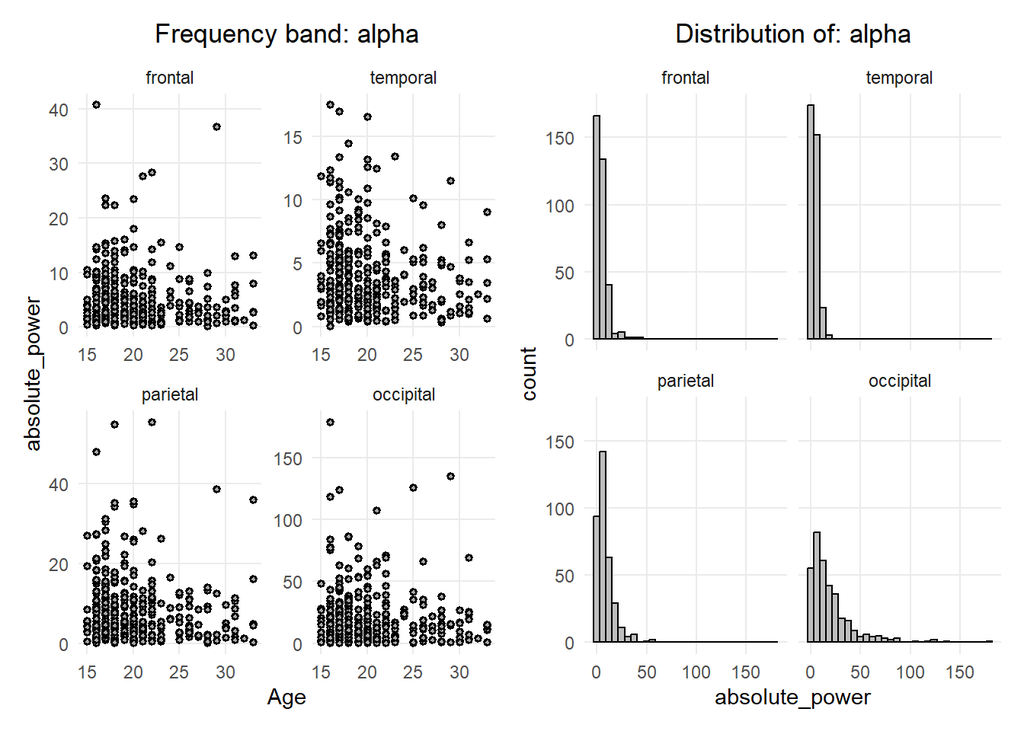

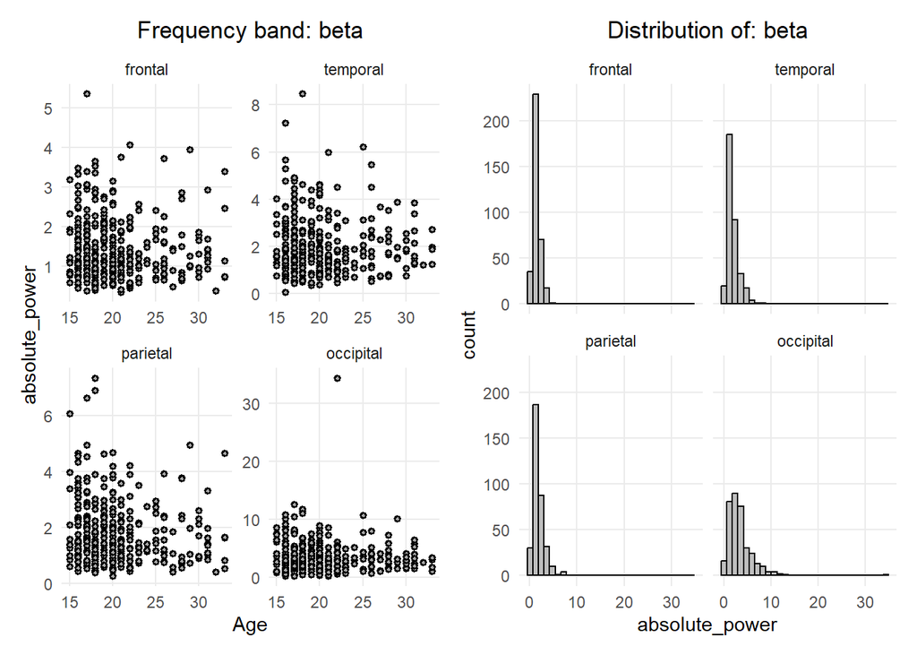

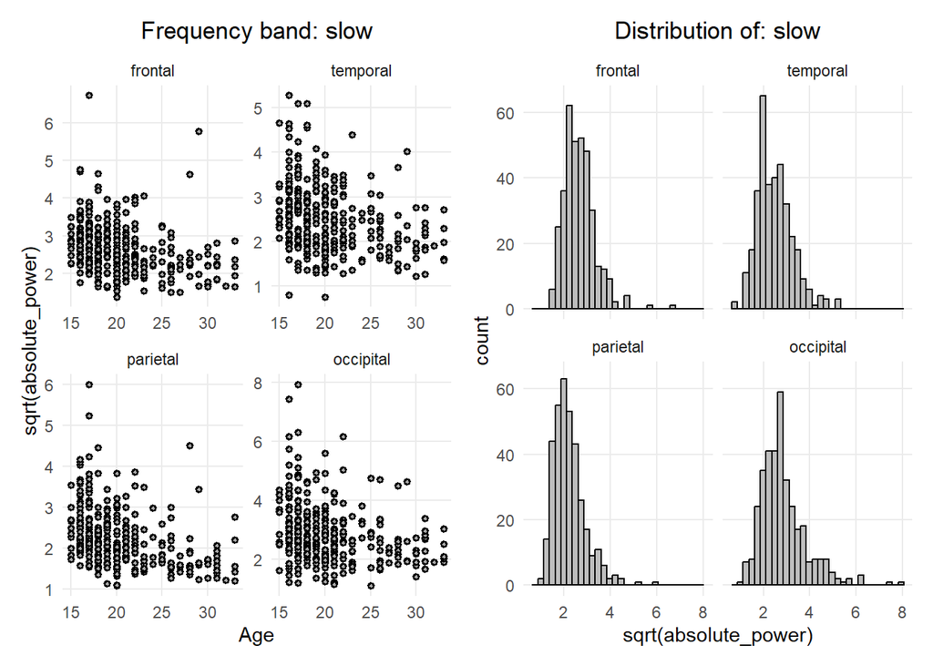

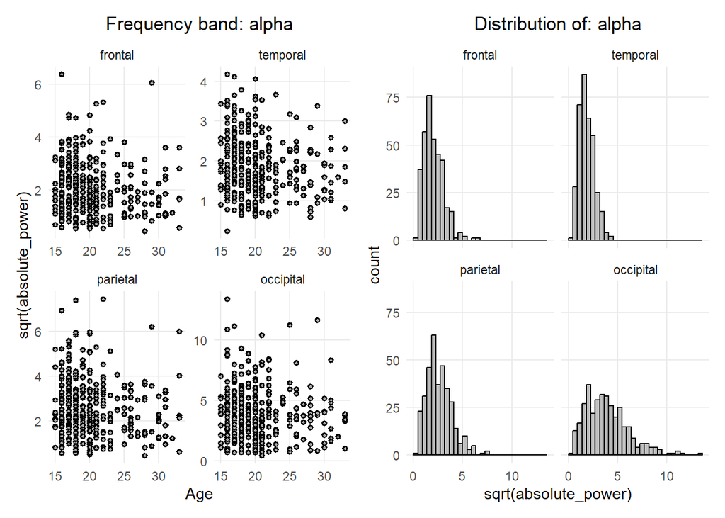

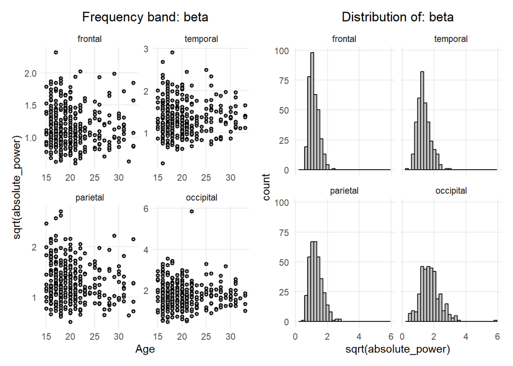

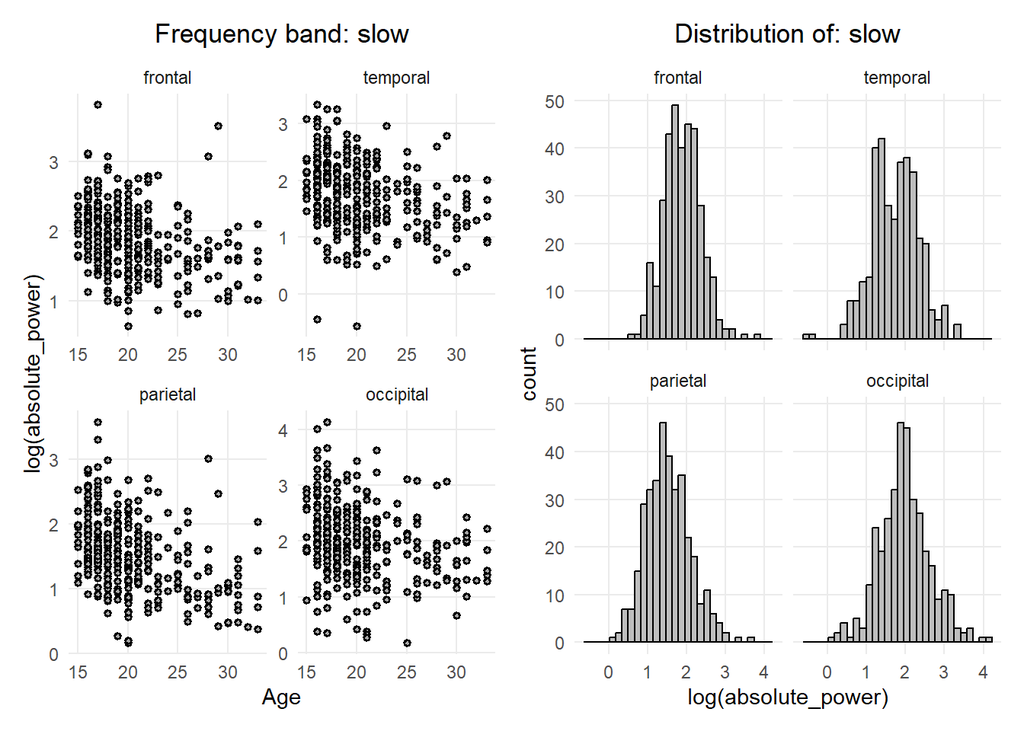

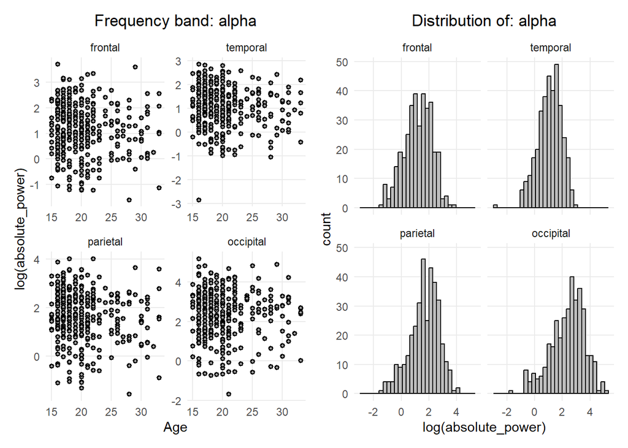

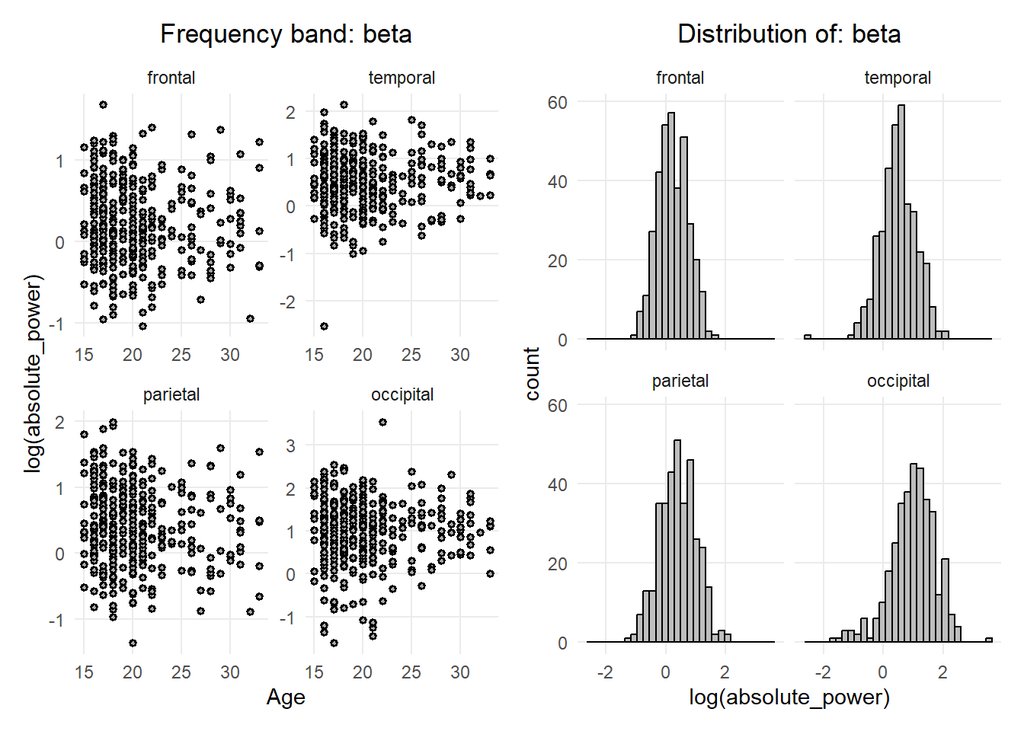

# Create Spelling Performance Group Using Fitted Values from Quadratic to Plateau Model

[We deleted the section before showing a scatterplot between Age and Spelling Ability because who cares, we show the same thing below but with more information]

The advantage of this approach is that it basically categorizes poor spellers as individuals who performed poorly in comparison to individuals of a similar age. Also, the spelling ability scores were derived from a much larger sample, actually from the sample of all IDs that had spelling data. This is good because that sample was 661 subjects. Now while I am no IRT expert, I think this large of a sample size plus the fact that there were poor performers in the spelling task based on raw scores, justifies that standardized values, which represent distance from the mean performers, is still capturing true poor spellers.

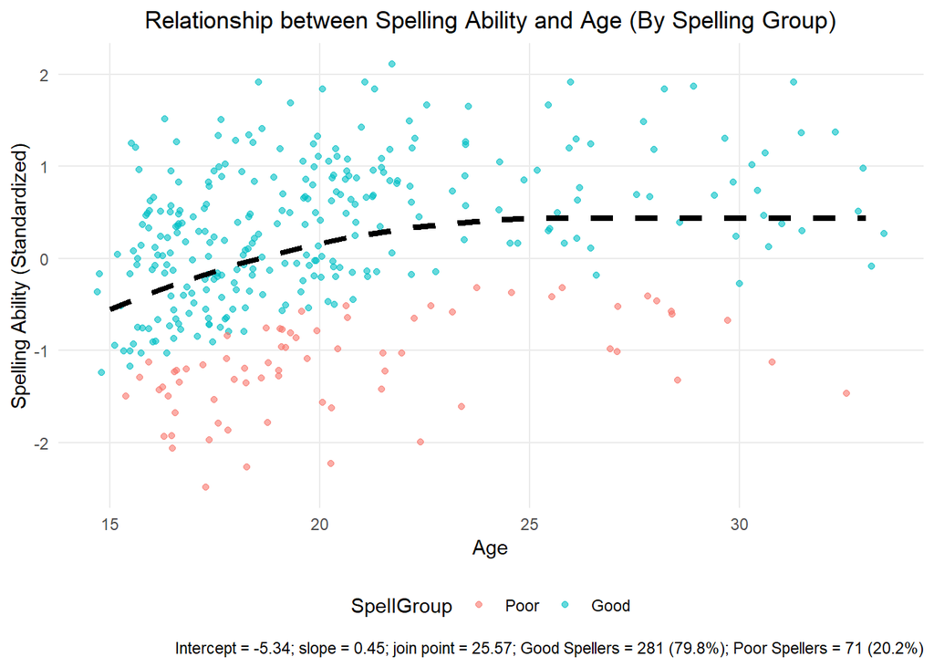

# Age and Spelling Group Tabulation Table (Contingency Table)

Now that we have created a spelling group factor, let’s see what the cell sample sizes are. We will bin people into age groups and then show within those bins, how many good and poor spellers there are.

Number of Good and Poor Spellers by Age Group

[output not shown]

### Visualize the Relationship Between Spelling and EEG power

Visually it looks like spelling ability does not seem to be predictive at all of rsEEG absolute power. This is preparing us for the fact that we are very likely not going to see any differences between good and poor spellers- their EEG activity looks the same.

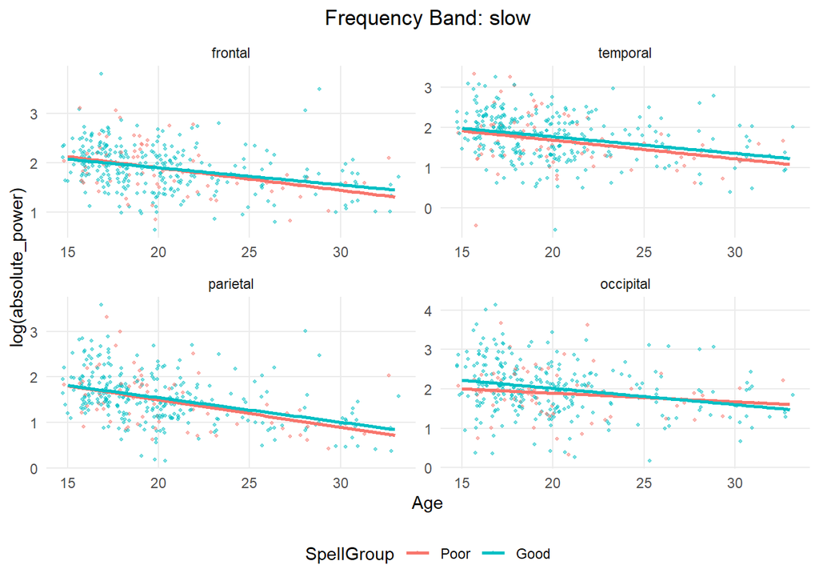

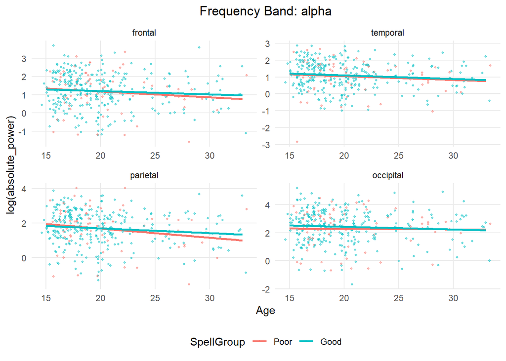

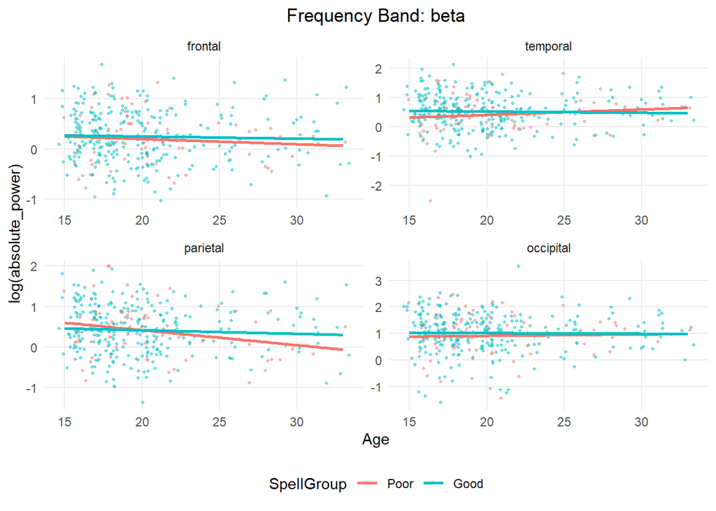

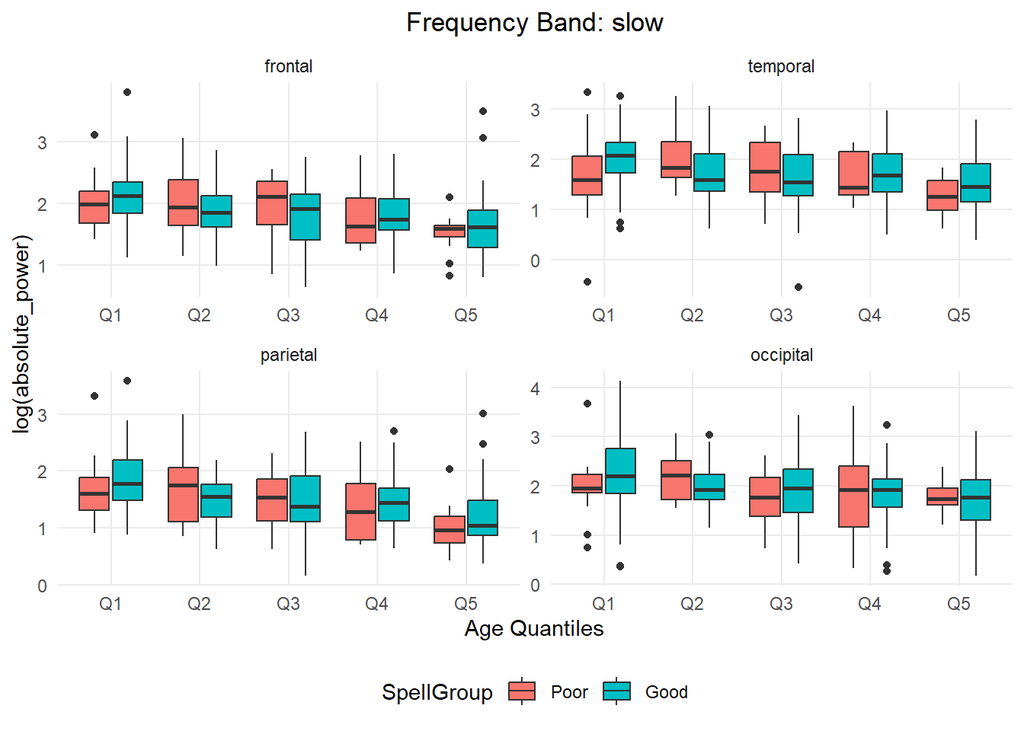

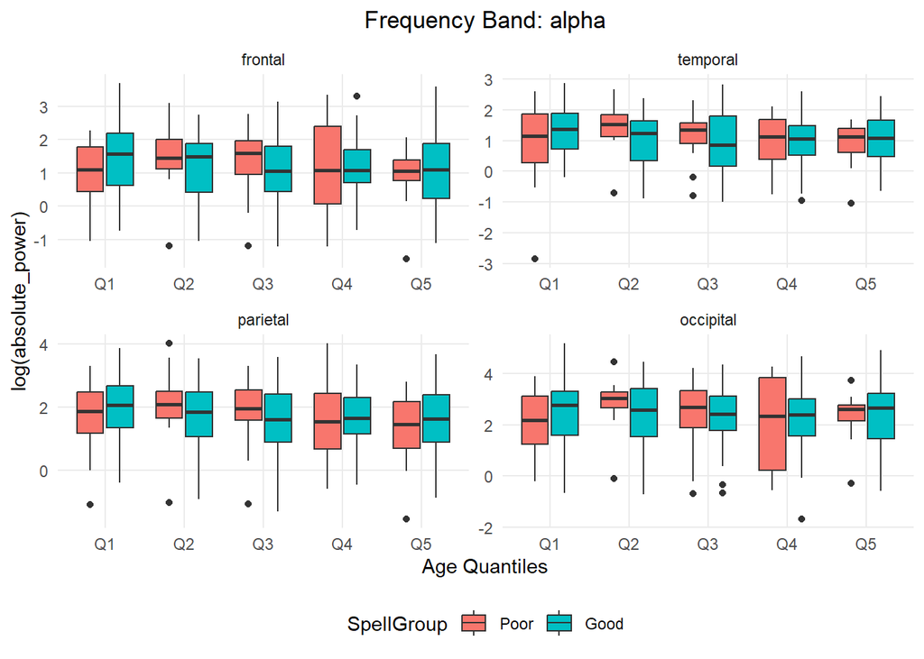

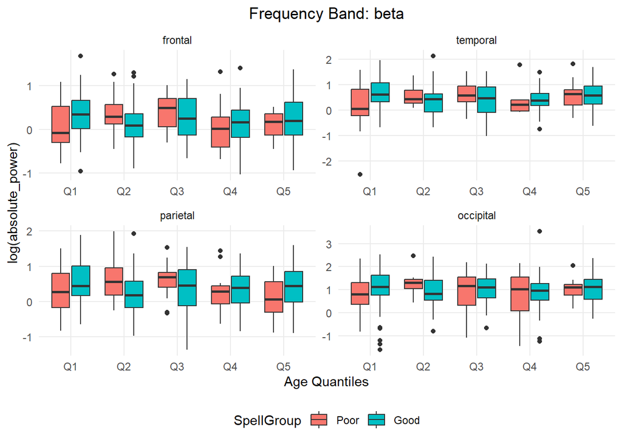

### Replicating Findings from Whitford (2007)

The goal here is to run the exact same statistics that was reported in Whitford et al. (2007) paper. They ran regular multiple regressions using data from 138 healthy participants. Specifically, they sqrt() transformed the power values and they log transformed the Age variable. They did this (specifically the transforming of the outcome) to have normal looking data so a regression would be appropriate (rather than a glm).

Their multiple regression had the factors log(Age) and sex. They ran a single multiple regression for each EEG region (frontal, temporal, parietal, occipital) and frequency band (slow, alpha, beta) combination- no mixed models were used. Since this approach produces 12 p-values (if only interested in log(Age)), they used **alpha criterion level of 0.01**.

Thus, we will be fitting the following model 12 times and showcasing how well the model fit our data. We will be using the natural log instead because it does not make sense to interpret a sqrt() outcome of the residual assumptions are violated in the process. We will also take the natural log of age to be consistent.

log(absolute_power) ~ b0 + b1_sex + b2_log(age)

Our results show something interesting. For starters, only the slow frequency band was predicted by log(Age), the other frequencies were not. This is very different from Whitford where basically every regression produced a significant log(age) at the 0.01 alpha criterion except for the Alpha/Frontal Lobe combination. Next, the produced QQ plots do not look so good- there are several cases where the relationship between the residual values and theoretical quantiles do not look linear. However, if we change our outcome from sqrt(absolute_power) to log(absolute_power), the Q-Q plots produced look much better. We might have to do this just because our data might be more skewed that the data used by Whitford.

| topography | FB | term | estimate | std.error | statistic | p.value | significant |
| --- | --- | --- | --- | --- | --- | --- | --- |
| parietal | slow | log(Age) | -1.241 | 0.141 | -8.797 | < 0.001 | Y |
| occipital | slow | log(Age) | -0.870 | 0.173 | -5.017 | < 0.001 | Y |
| frontal | slow | log(Age) | -0.834 | 0.123 | -6.778 | < 0.001 | Y |
| temporal | slow | log(Age) | -0.974 | 0.156 | -6.261 | < 0.001 | Y |
| parietal | alpha | log(Age) | -0.745 | 0.290 | -2.571 | 0.011 | N |
| occipital | alpha | log(Age) | -0.381 | 0.337 | -1.132 | 0.258 | N |
| frontal | alpha | log(Age) | -0.486 | 0.275 | -1.767 | 0.078 | N |
| temporal | alpha | log(Age) | -0.508 | 0.234 | -2.171 | 0.031 | N |
| parietal | beta | log(Age) | -0.346 | 0.164 | -2.108 | 0.036 | N |
| occipital | beta | log(Age) | -0.067 | 0.204 | -0.327 | 0.744 | N |
| frontal | beta | log(Age) | -0.151 | 0.138 | -1.090 | 0.276 | N |
| temporal | beta | log(Age) | -0.046 | 0.158 | -0.289 | 0.773 | N |

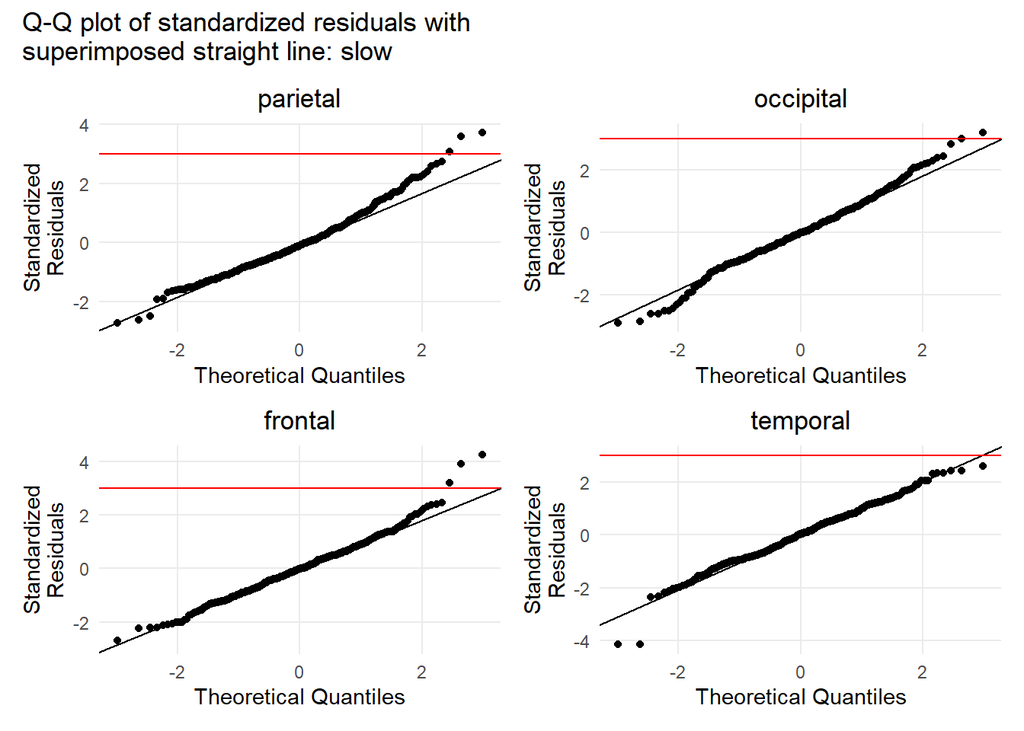

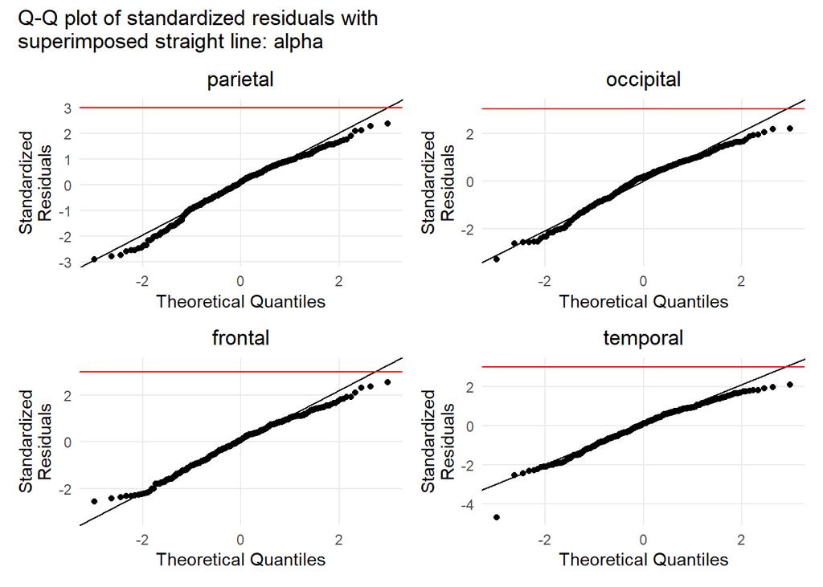

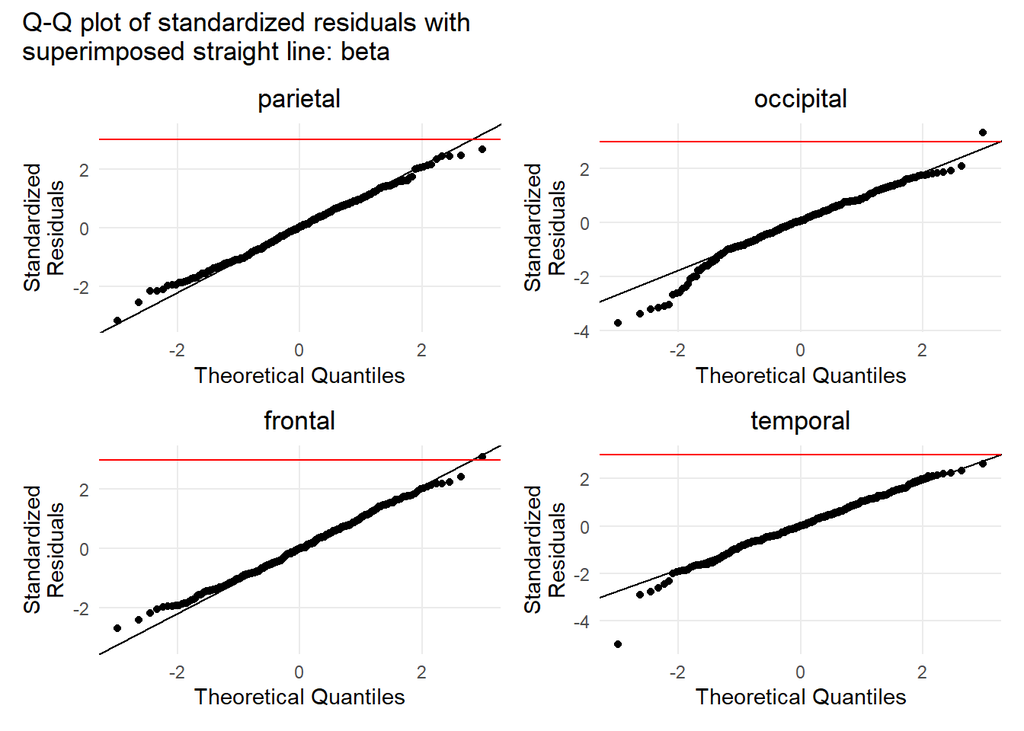

### Fitting a Quadratic Plateau Mixed-Effect Models (EEG ~ Age + (1|ID))

From our results above running regression models, we see that only for ‘slow’ waves was there a significant relationship between age and absolute power. This effect was robust and present across the different topographies (frontal, temporal, parietal, occipital). By looking at the beta coefficients, we see that they are all **negative**, which means that with age absolute power across all topographical regions is decreasing for slower frequencies.

However, the higher frequencies such as ‘alpha’ and ‘beta’ produced non significant beta estimates, meaning that with age the absolute power in these frequencies is constant.

Since there is no change in power for ‘alpha’ and ‘beta’ with age, then it does not make sense to use a Quadratic to Plateau model on that data. However, it does make sense to run this model for the ‘slow’ frequency absolute power data.

Thus, this section will be running a Quadratic to Plateau model where log(absolute power) for ‘slow’ frequency will be modeled as a function of age (centered at min age). We will need to **subset** the data to only have ‘slow’ absolute power values. Thus, our original dataset of 352 (IDs) * 12 = 4,224 observations will be reduced to 352 * 4 = 1,408 observations.

First,we will just see how absolute power is explained from age alone. This will be our ‘mod0’. The estimates produced will be the:

- The intercept (log absolute power when age = min sample age)
- The slope (linear slope representing age and absolute power relationship at the min sample age)
- Join point (the age value when the plateau occurs)

### Results of ‘Slow’ absolute power as a function of age (Quadratic to Plateau Model)

Below we will be showing the summary of the Quadratic to Plateau Model showcasing ‘slow’ log(absolute power) as a function of age. Notice that every parameter is significant. Let’s cover each one.

- **Intercept**: The intercept is 2.10, which represents the log of absolute power at min age of the sample (15 years). The mean of log absolute power is 1.7892, thus the intercept is showing higher log absolute power at the age of 15 compared the average in the sample.
- **Slope**: The slope is -0.0824, which is the linear relationship between age and log absolute power at the age of 15. This means that at a different age, this slope value will be different and it will be closer to 0 in comparison. Overall the takeaway is that this shows absolute power is decreasing with age, as we would have expected.
- **Join point**: The join point is 16.44. This is the value of x where the quadratic to plateau model turns into a plateau. In other words, the age when log absolute power levels out and stops decreasing. Since our age variable was centered to age 15, then this means the join point is 15 + 16.44 = 31.44 years. However, the standard errors are quite large (4.56). Therefore, we can be 95% confident that the true age of when absolute power decreases is between 22.5 to 40.4.

**Limitations**: The obvious problem in the model is how large the standard errors are for the join point. This can tell us that we do not have enough data points for the later values of x (older participants), which makes estimating a precise join point difficult. Another thing to notice is that this will only get worse as we subset our data further, like we plan to do when introducing ‘Spell Group’ as a factor, which is a between group factor. I think (Leo) that introducing between group factors, unlike within group, will require a larger sample size because estimates are now being derived by only using that subset of data, rather than the whole like we are doing now.

To further increase our confidence that our interpretation of these estimates are correct, specifically the interpretation of the slope (we are working with a nonlinear model), we can use the `slope()` function from the marginaleffects package to derive the slope representing the linear relationship between x (age) and y (log absolute power) at any value of x. We see that when we do this for 0 (age 15) that it produces the same slope as the one from the model summary.

```
Nonlinear mixed-effects model fit by maximum likelihood
  Model: log_absolute_slow_power ~ SSquadp3xs(Age_min_c, a, b, xs)
  Data: slow_dat
       AIC      BIC    logLik
  1987.286 2013.535 -988.6429

Random effects:
 Formula: a ~ 1 | ID
                a  Residual
StdDev: 0.4068244 0.3974724

Fixed effects:  list(a ~ 1, b ~ 1, xs ~ 1)
       Value Std.Error   DF  t-value p-value
a   2.103150  0.058276 1056 36.08969   0e+00
b  -0.082471  0.020045  349 -4.11436   0e+00
xs 16.442413  4.560299  349  3.60556   4e-04
 Correlation:
   a      b
b  -0.867
xs -0.597  0.854

Standardized Within-Group Residuals:
        Min          Q1         Med          Q3         Max
-4.36864831 -0.61431062  0.08890103  0.55876213  3.10794354

Number of Observations: 1408
Number of Groups: 352
```

```
 Age_min_c Estimate Std. Error     z Pr(>|z|)    S  2.5 %  97.5 %
         0  -0.0825       0.02 -4.12   <0.001 14.7 -0.122 -0.0432

Term: Age_min_c
Type: response
Comparison: dY/dX
```

While on the same topic, we can also generate a plot of our data as a scatterplot with the fitted values embedded on top.

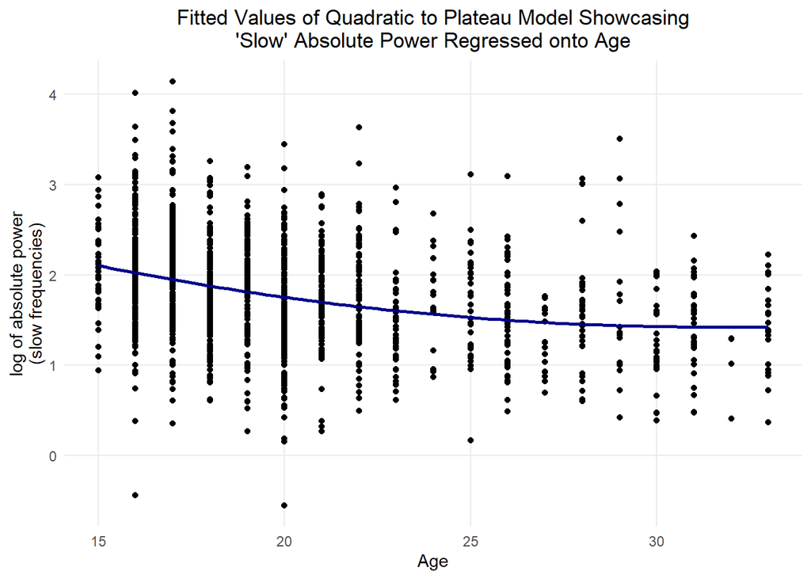

### Adding Topography to the Quadratic to Plateau Model

Now, we will increase the complexity of the model by introducing the factor **topography**. In typical regression, a factor will produce estimates that corresponds directly to the intercept. However, in quadratic to plateau models (and nonlinear models in general), we have the option to also generate estimates for the slope for k-1 levels of topography, the join point, or any combination of them (plus the intercept). Thus, we will create three models that include topography, starting with a model that estimates more intercepts (mod1), then adds slopes (mod2), and lastly adds join points (mod3). Afterwards, we will use the anova() function to compare the models and show us which of the three best explains our data. However, we have reason to suspect that ‘mod3’ will probably not be the best, mainly because there are not many participants at the later levels of age, making the generated estimate (join point) have higher standard errors.

Additionally, the topography factor will be **effect coded**, meaning that the resulting parameters for the levels of the factors (those that get estimated) will show mean differences compared to a grand average from the levels of topography, not from one reference level.

```
     Model df      AIC      BIC    logLik   Test   L.Ratio p-value
mod1     1  8 1675.155 1717.154 -829.5773
mod2     2 11 1670.259 1728.008 -824.1297 1 vs 2 10.895207  0.0123
mod3     3 14 1674.183 1747.682 -823.0917 2 vs 3  2.075883  0.5568
```

### Results of ‘Slow’ absolute power as a function of age with Topography (Quadratic to Plateau Model)

```
Nonlinear mixed-effects model fit by maximum likelihood
  Model: log_absolute_slow_power ~ SSquadp3xs(Age_min_c, a, b, xs)
  Data: slow_dat
       AIC      BIC    logLik
  1670.259 1728.008 -824.1297

Random effects:
 Formula: a ~ 1 | ID
        a.(Intercept)  Residual
StdDev:     0.4196912 0.3401168

Fixed effects:  list(a ~ topography_ec, b ~ topography_ec, xs ~ 1)
                             Value Std.Error   DF  t-value p-value
a.(Intercept)             2.155954  0.060786 1049 35.46814  0.0000
a.topography_ectemporal  -0.113057  0.048655 1049 -2.32368  0.0203
a.topography_ecoccipital  0.103381  0.048459 1049  2.13337  0.0331
a.topography_ecparietal  -0.249392  0.050165 1049 -4.97144  0.0000
b.(Intercept)            -0.065149  0.017391  350 -3.74621  0.0002
b.topography_ectemporal  -0.011129  0.010577 1049 -1.05221  0.2929
b.topography_ecoccipital -0.003803  0.010371 1049 -0.36674  0.7139
b.topography_ecparietal  -0.031376  0.012076 1049 -2.59821  0.0095
xs                       18.194404  5.444158 1049  3.34201  0.0009
 Correlation:
                         a.(In) a.tpgrphy_ct a.tpgrphy_cc a.tpgrphy_cp b.(In)
a.topography_ectemporal  -0.354
a.topography_ecoccipital -0.384  0.501
a.topography_ecparietal  -0.268  0.505        0.491
b.(Intercept)            -0.839  0.180        0.228        0.049
b.topography_ectemporal   0.237 -0.845       -0.421       -0.454       -0.135
b.topography_ecoccipital  0.304 -0.428       -0.847       -0.427       -0.242
b.topography_ecparietal   0.059 -0.410       -0.380       -0.835        0.129
xs                       -0.446 -0.095       -0.033       -0.260        0.744
                         b.tpgrphy_ct b.tpgrphy_cc b.tpgrphy_cp
a.topography_ectemporal
a.topography_ecoccipital
a.topography_ecparietal
b.(Intercept)
b.topography_ectemporal
b.topography_ecoccipital  0.503
b.topography_ecparietal   0.527        0.465
xs                        0.209        0.073        0.516

Standardized Within-Group Residuals:
        Min          Q1         Med          Q3         Max
-4.86453619 -0.44058117  0.01690486  0.51489530  2.97645602

Number of Observations: 1408
Number of Groups: 352
```

```
 Age_min_c topography_ec Estimate Std. Error     z Pr(>|z|)    S  2.5 % 97.5 %
         0      temporal  -0.0763      0.019 -4.01   <0.001 14.0 -0.114 -0.039

Term: Age_min_c
Type: response
Comparison: dY/dX
```

To visualize the fitted values on our sample data, we need to use the `expand.grid()` function. We did this for the age only model, but since it was straightforward then there was no need to create a justification of how we managed to do that. For this model though, what we are essentially doing is creating a data frame of level combination of predictors that will then function as inputs to our model to generate fitted values. So to do this, we will create a vector for centered age that ranges from the min to the max values of that variable (centered age) for each level of topography (100 values of centered age). Below we can use the `xtabs()` function to confirm the data frame of predictor level combinations was created correctly, which is was since we see 100 values for each topography level.

```
topography_ec
  frontal  temporal occipital  parietal
      100       100       100       100
```

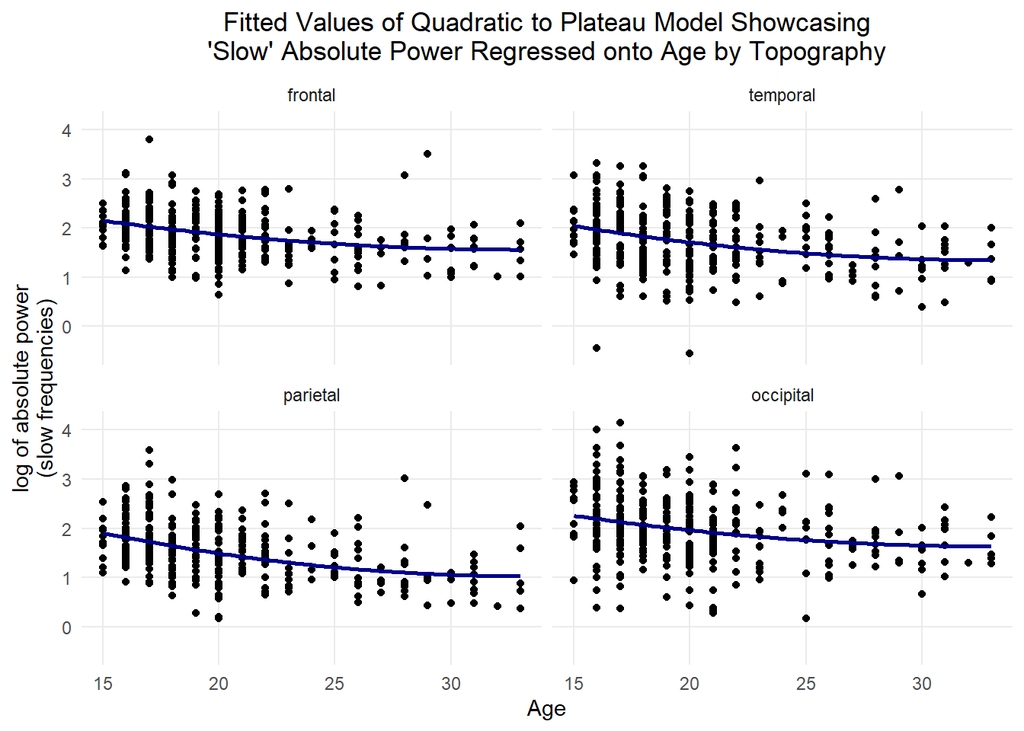

### Adding Spelling Group to the Quadratic to Plateau Model

The main focus for our analysis to investigate whether there are group differences in absolute power between good and poor spellers. We are hypothesizing that poor spellers will have higher absolute power for lower frequencies than good spellers, which will resemble findings reported in the literature for children between 7-14 years of age. Thus, we will estimate an intercept for spell group, which will represent the difference in absolute power between groups at the age 15.

The next thing will be to address the slopes. Assuming that there will be differences between the intercepts between good and poor spellers, we will then need to test if the rate of change is different between the two groups. This is because if the slopes are the same, then essentially that indicates that absolute power between the two will continue to be different with age. However, if the slopes do differ, especially with the slope of the poor spellers being larger than the good spellers, then that would indicate that absolute power will become similar between the two groups at the end of development. In other words, that would show evidence for a ‘catching’ up in physiological maturation.

Additionally, we should also check for differences in join points between groups, or at what age does absolute power plateau for both groups. While this will be difficult to estimate due to our sample, we still need to incorporate it to check whether or not there are differences in when maturation occurs between groups.

We also thought that maybe for this model, since we are increasing its complexity by adding more estimates to the intercept, slope and join point, that maybe we could reduce model complexity by not estimating the k-1 slopes for topography. Thus, below we will be comparing both models against each other.

Also note that we also specified models with topography and spell group interactions and they did not significantly explain more variance than the simple models. These models are not shown here since they took up space and it was also a bit of p-hacking if we think about it.

```
            Model df      AIC      BIC    logLik   Test  L.Ratio p-value
mod_groupv1     1 11 1680.218 1737.968 -829.1092
mod_groupv2     2 14 1675.265 1748.764 -823.6325 1 vs 2 10.95336   0.012
```

### Results of ‘Slow’ absolute power as a function of age with Topography Between Spelling Group (Quadratic to Plateau Model)

The best fitting model was the one that still had slopes estimated for k-1 topography levels, so that is the one that we will be interpreting below. However, since this is our final model for the analysis, we will be interpreting the model not using the p-values directly from the output table, but the ones that we obtain using follow-up tests. This is so we can add adjustments to correct for multiple comparison. Additionally this will allow us to generate estimates for all levels of topography rather than just k-1 levels. Honestly, using **marginal effects** below, all previous models can essentially be ignored. Their reasoning for specification was to compare the results from these model back to them, to see if there are any weird discrepancies (ex: having a positive slope rather than negative or something crazy like that).

Unfortunately, the omnibus test that we would typically use, aka the one from the Anova() function does not work here, so we will be ignoring that.

Okay so there is a lot of information down below, we will just make sense of the follow-up tests rather than the original model summary output. However, what is good about the model output is that it shows 1408 observations and 352 groups, which aligns with our dataset.

**Parameter a: The Intercept**

- Starting with **topography**, the estimated marginal means are showing the mean log absolute power for each level of topography when centered age is equal to 0 (age is 15 years). We see that all of them except for parietal are 2 log absolute power or larger. We can then do pairwise comparisons to test whether log absolute power differences between levels of topography. Looking at the p-values, we see that there are significant differences between frontal and parietal, temporal and occipital, temporal and parietal, and occipital and parietal. Essentially, from this we can see that in the parietal region, log absolute power tends to be lower overall compared to the other regions after adjusting for multiple comparisons (tukey)
- Next with **spelling group**, we can see the estimates between poor (2.03) and good (2.10) spellers. Instantly we can see that the values are very close to each other, not only that but **unexpectedly**, there is more log absolute power for good spellers than poor spellers. Next we investigate whether these means when centered age is 0 (age is 15 years) are significantly different from each other, and unsurprisingly they are not (p = 0.5844).

**Parameter b: The Slope**

- **Note**: The following slope estimates where all calculated from age centered being equal to 0 (age is 15 years). To do this, we created a reference grid that specified age centered being equal to 0, and then using that grid to obtain estimated slopes. This is important because failing to do this step would have produced either a) derivatives (slopes) averaged across all data points which include all age data points or b) an estimated slope at the sample mean of age centered. Those would have been **main effects**, but we don’t really care for that since what we really want is the slope that corresponds with age centered being at 0.
- Starting with **topography**, we get the **simple slopes** of all levels of topography, where they are all negative and are all significant, indicating that with age log absolute power is decreasing, as we would expect. Next we use pairwise comparisons to see if the rate of change differs by topographical region. After controlling for multiple comparison using the Benjamini-Hochberg (BH) procedure, we found no differences in slope comparisons.
- Next with **spelling group**, we see that the simple slopes for poor spellers is -0.0691 and good spellers is -0.0766, which look similar, with the slope being slightly stronger for good spellers than poor spellers. Not surprisingly, the slope differences between the two were not significant.

**Parameter xs: The Join Point**

- We only modeled the join point using the **spell group** factor. We can see that the age for log absolute power plateau in poor spellers is 21.8 + 15 = 36.8 and in good spellers is 17.9 + 15 = 32.9. Again these numbers do not really make sense and the standard errors are large, especially for the poor spelling group with was 17.10 unlike the good spellers which was 5.52. How large these standard errors are really undermine the model entirely I would say. Regardles there was no significant difference in the join point between the two groups.

```
Nonlinear mixed-effects model fit by maximum likelihood
  Model: log_absolute_slow_power ~ SSquadp3xs(Age_min_c, a, b, xs)
  Data: slow_dat
       AIC      BIC    logLik
  1675.265 1748.764 -823.6325

Random effects:
 Formula: a ~ 1 | ID
        a.(Intercept)  Residual
StdDev:     0.4191127 0.3400921

Fixed effects:  list(a ~ topography_ec + SpellGroup, b ~ topography_ec + SpellGroup,      xs ~ SpellGroup)
                             Value Std.Error   DF   t-value p-value
a.(Intercept)             2.093682  0.124816 1046 16.774169  0.0000
a.topography_ectemporal  -0.111707  0.048379 1046 -2.309010  0.0211
a.topography_ecoccipital  0.101369  0.048127 1046  2.106285  0.0354
a.topography_ecparietal  -0.250676  0.050084 1046 -5.005062  0.0000
a.SpellGroupGood          0.072489  0.132975  350  0.545131  0.5860
b.(Intercept)            -0.057772  0.033806 1046 -1.708910  0.0878
b.topography_ectemporal  -0.011383  0.010444 1046 -1.089914  0.2760
b.topography_ecoccipital -0.003272  0.010187 1046 -0.321137  0.7482
b.topography_ecparietal  -0.030818  0.012065 1046 -2.554284  0.0108
b.SpellGroupGood         -0.007494  0.036523 1046 -0.205195  0.8375
xs.(Intercept)           21.822011 17.169410 1046  1.270982  0.2040
xs.SpellGroupGood        -3.926696 16.587427 1046 -0.236727  0.8129
 Correlation:
                         a.(In) a.tpgrphy_ct a.tpgrphy_cc a.tpgrphy_cp a.SpGG
a.topography_ectemporal  -0.152
a.topography_ecoccipital -0.181  0.500
a.topography_ecparietal  -0.083  0.507        0.489
a.SpellGroupGood         -0.874 -0.019       -0.006       -0.051
b.(Intercept)            -0.847  0.065        0.109       -0.039        0.743
b.topography_ectemporal   0.079 -0.842       -0.418       -0.459        0.035
b.topography_ecoccipital  0.139 -0.426       -0.844       -0.424        0.010
b.topography_ecparietal  -0.048 -0.411       -0.372       -0.833        0.081
b.SpellGroupGood          0.726  0.026        0.007        0.067       -0.845
xs.(Intercept)           -0.501 -0.082       -0.024       -0.214        0.434
xs.SpellGroupGood         0.482  0.056        0.016        0.145       -0.488
                         b.(In) b.tpgrphy_ct b.tpgrphy_cc b.tpgrphy_cp b.SpGG
a.topography_ectemporal
```

[output cut: 14 more lines]

```
a.SpellGroupGood
b.(Intercept)
b.topography_ectemporal
b.topography_ecoccipital
b.topography_ecparietal
b.SpellGroupGood
xs.(Intercept)
xs.SpellGroupGood        -0.947

Standardized Within-Group Residuals:
        Min          Q1         Med          Q3         Max
-4.86967345 -0.43811885  0.01603704  0.51037054  2.97702960

Number of Observations: 1408
Number of Groups: 352
```

```
$emmeans
 topography_ec emmean     SE  df lower.CL upper.CL t.ratio p.value
 frontal         2.13 0.0738 350     1.98     2.28  28.868 <0.0001
 temporal        2.02 0.0763 350     1.87     2.17  26.464 <0.0001
 occipital       2.23 0.0745 350     2.08     2.38  29.964 <0.0001
 parietal        1.88 0.0811 350     1.72     2.04  23.180 <0.0001

Results are averaged over the levels of: SpellGroup
Confidence level used: 0.95

$contrasts
 contrast             estimate     SE   df lower.CL upper.CL t.ratio p.value
 frontal - temporal      0.112 0.0482 1046  -0.0122   0.2357   2.319  0.0944
 frontal - occipital    -0.101 0.0479 1046  -0.2247   0.0219  -2.115  0.1488
 frontal - parietal      0.251 0.0499 1046   0.1224   0.3790   5.027 <0.0001
 temporal - occipital   -0.213 0.0480 1046  -0.3367  -0.0895  -4.436 <0.0001
 temporal - parietal     0.139 0.0487 1046   0.0137   0.2643   2.854  0.0228
 occipital - parietal    0.352 0.0495 1046   0.2247   0.4794   7.115 <0.0001

Results are averaged over the levels of: SpellGroup
Confidence level used: 0.95
Conf-level adjustment: tukey method for comparing a family of 4 estimates
P value adjustment: tukey method for comparing a family of 4 estimates
```

```
$emmeans
 SpellGroup emmean    SE  df lower.CL upper.CL t.ratio p.value
 Poor         2.03 0.123 350     1.79     2.27  16.518 <0.0001
 Good         2.10 0.060 350     1.98     2.22  35.041 <0.0001

Results are averaged over the levels of: topography_ec
Confidence level used: 0.95

$contrasts
 contrast    estimate    SE  df lower.CL upper.CL t.ratio p.value
 Poor - Good  -0.0725 0.132 350   -0.333    0.188  -0.547  0.5844

Results are averaged over the levels of: topography_ec
Confidence level used: 0.95
```

```
 topography_ec Estimate Std. Error     z Pr(>|z|)    S  2.5 %  97.5 %
     frontal    -0.0615     0.0203 -3.03  0.00244  8.7 -0.101 -0.0217
     occipital  -0.0648     0.0208 -3.11  0.00185  9.1 -0.106 -0.0240
     parietal   -0.0923     0.0254 -3.64  < 0.001 11.8 -0.142 -0.0426
     temporal   -0.0729     0.0221 -3.30  < 0.001 10.0 -0.116 -0.0296

Term: Age_min_c
Type: response
Comparison: dY/dX
```

```
 Term               Hypothesis Estimate Std. Error      z Pr(>|z|)   S    2.5 %
   b1 (occipital) - (frontal)  -0.00327     0.0101 -0.323   0.8575 0.2 -0.02924
   b2 (parietal) - (frontal)   -0.03082     0.0120 -2.565   0.0619 4.0 -0.06166
   b3 (temporal) - (frontal)   -0.01138     0.0104 -1.094   0.8222 0.3 -0.03810
   b4 (parietal) - (occipital) -0.02755     0.0116 -2.366   0.0899 3.5 -0.05744
   b5 (temporal) - (occipital) -0.00811     0.0103 -0.791   0.8575 0.2 -0.03443
   b6 (temporal) - (parietal)   0.01944     0.0109  1.781   0.2999 1.7 -0.00859
   97.5 %
 2.27e-02
 2.82e-05
 1.53e-02
 2.34e-03
 1.82e-02
 4.75e-02
```

```
 SpellGroup Estimate Std. Error     z Pr(>|z|)    S  2.5 %   97.5 %
       Good  -0.0766     0.0194 -3.95   <0.001 13.7 -0.115 -0.03863
       Poor  -0.0691     0.0345 -2.01   0.0448  4.5 -0.137 -0.00161

Term: Age_min_c
Type: response
Comparison: dY/dX
```

```
      Hypothesis Estimate Std. Error     z Pr(>|z|)   S   2.5 % 97.5 %
 (Poor) - (Good)  0.00749     0.0364 0.206    0.837 0.3 -0.0639 0.0789

Type: response
```

```
$emmeans
 SpellGroup emmean    SE   df lower.CL upper.CL t.ratio p.value
 Poor         21.8 17.10 1046   -11.72     55.4   1.276  0.2021
 Good         17.9  5.52 1046     7.07     28.7   3.243  0.0012

Confidence level used: 0.95

$contrasts
 contrast    estimate   SE   df lower.CL upper.CL t.ratio p.value
 Poor - Good     3.93 16.5 1046    -28.5     36.3   0.238  0.8121

Confidence level used: 0.95
```

Just like before we can obtain fitted values of the model to create a scatterplot showing the relationships. We do this by using the `expand.grid()` function, where we can make different level combinations of all three predictors of interest: age centered, topography, and spell group. With this we can basically generate 100 observations for each level combination of the factors and confirm that this was correct using `xtabs()`.

```
          topography_ec
SpellGroup frontal temporal occipital parietal
      Poor     100      100       100      100
      Good     100      100       100      100
```

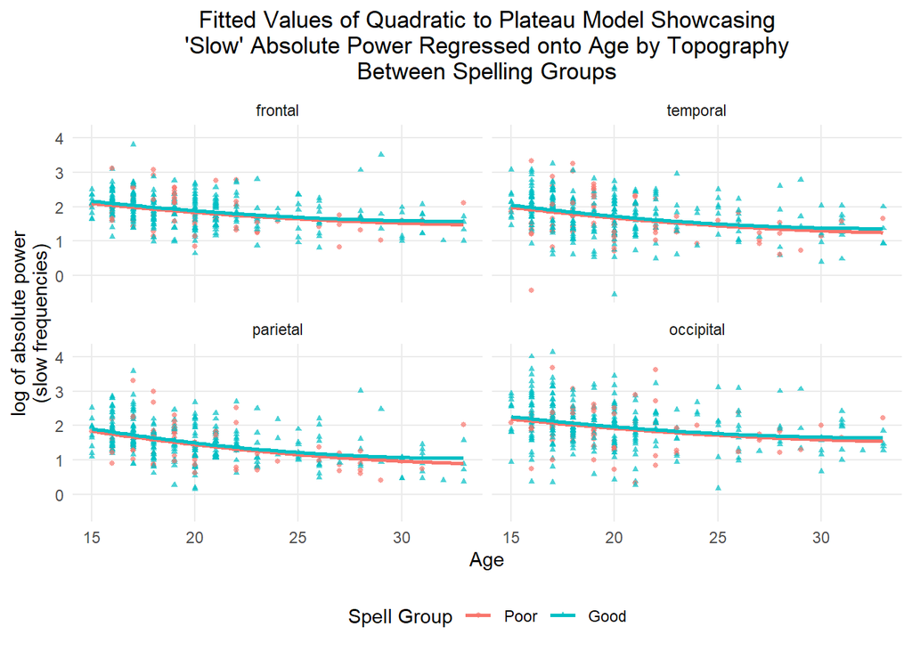